# gstore-eda

Alejandro Jiménez Rico

28 September 2018

In today’s competition we a’re challenged to analyze a Google Merchandise Store (also known as GStore, where Google swag is sold) customer dataset to predict revenue per customer.

Finally, we have a competition more R-oriented. Our moment to shine.

In this notebook, I’ll try to explore the given dataset and make some inferences along the way in order to build a baseline model to get started.

```r
library(tidyverse)
library(data.table)
library(jsonlite)
library(lubridate)
library(moments)

library(tictoc)

library(caret)
library(xgboost)
library(viridis)
library(harrypotter)

library(lime)
```

# Retrieving Data

As always, we have to start by taking a look at the actual data.

```r
test  <- fread("data/test.csv")
test %>% glimpse()
```

```
## Observations: 804,684
## Variables: 12
## $ channelGrouping      <chr> "Organic Search", "Organic Search", "Orga...
## $ date                 <int> 20171016, 20171016, 20171016, 20171016, 2...
## $ device               <chr> "{\"\"browser\"\": \"\"Chrome\"\", \"\"br...
## $ fullVisitorId        <chr> "6167871330617112363", "06436976409779156...
## $ geoNetwork           <chr> "{\"\"continent\"\": \"\"Asia\"\", \"\"su...
## $ sessionId            <chr> "6167871330617112363_1508151024", "064369...
## $ socialEngagementType <chr> "Not Socially Engaged", "Not Socially Eng...
## $ totals               <chr> "{\"\"visits\"\": \"\"1\"\", \"\"hits\"\"...
## $ trafficSource        <chr> "{\"\"campaign\"\": \"\"(not set)\"\", \"...
## $ visitId              <int> 1508151024, 1508175522, 1508143220, 15081...
## $ visitNumber          <int> 2, 1, 1, 1, 1, 1, 1, 1, 6, 1, 1, 1, 1, 1,...
## $ visitStartTime       <int> 1508151024, 1508175522, 1508143220, 15081...
```

```r
rm(test)
gc()
```

```
##           used  (Mb) gc trigger  (Mb) max used  (Mb)
## Ncells 2516287 134.4    7557738 403.7  4449561 237.7
## Vcells 5897074  45.0   23342969 178.1 24752680 188.9
```

Do you notice those weird patterns in the columns `device`, `geoNetwork`, `totals` and `trafficSource`? This isn’t suppose to be a `.csv` file. It has tree-developed features that we need to flatten out.

```r
flatten <- function(x){

    pre_flatten <- . %>%
  str_c(., collapse = ",") %>%
  str_c("[", ., "]") %>%
  fromJSON(flatten = T)

    x %>%
  bind_cols(pre_flatten(.$device)) %>%
  bind_cols(pre_flatten(.$geoNetwork)) %>%
  bind_cols(pre_flatten(.$trafficSource)) %>%
  bind_cols(pre_flatten(.$totals)) %>%
  select(-device, -geoNetwork, -trafficSource, -totals) %>%
    return()
}


train <- read_csv("data/train.csv") %>% sample_n(1e4)  %>% flatten() %>% data.table()
test  <- read_csv("data/test.csv") %>% sample_n(1e4)  %>%  flatten() %>% data.table()
glimpse(train)
```

```
## Observations: 10,000
## Variables: 55
## $ channelGrouping                     <chr> "Direct", "Organic Search"...
## $ date                                <int> 20170630, 20170428, 201610...
## $ fullVisitorId                       <chr> "0458080076911939213", "00...
## $ sessionId                           <chr> "0458080076911939213_14988...
## $ socialEngagementType                <chr> "Not Socially Engaged", "N...
## $ visitId                             <int> 1498824993, 1493415915, 14...
## $ visitNumber                         <int> 1, 1, 1, 10, 3, 1, 1, 1, 1...
## $ visitStartTime                      <int> 1498824993, 1493415915, 14...
## $ browser                             <chr> "Chrome", "Chrome", "Inter...
## $ browserVersion                      <chr> "not available in demo dat...
## $ browserSize                         <chr> "not available in demo dat...
## $ operatingSystem                     <chr> "Android", "Windows", "Win...
## $ operatingSystemVersion              <chr> "not available in demo dat...
```

[output cut: 42 more lines]

```r
glimpse(test)
```

```
## Observations: 10,000
## Variables: 53
## $ channelGrouping                     <chr> "Organic Search", "Direct"...
## $ date                                <int> 20180412, 20180227, 201710...
## $ fullVisitorId                       <chr> "5683848361339266073", "78...
## $ sessionId                           <chr> "5683848361339266073_15235...
## $ socialEngagementType                <chr> "Not Socially Engaged", "N...
## $ visitId                             <int> 1523522728, 1519719766, 15...
## $ visitNumber                         <int> 1, 1, 1, 1, 1, 76, 1, 1, 1...
## $ visitStartTime                      <int> 1523522728, 1519719766, 15...
## $ browser                             <chr> "Chrome", "Firefox", "Chro...
## $ browserVersion                      <chr> "not available in demo dat...
## $ browserSize                         <chr> "not available in demo dat...
## $ operatingSystem                     <chr> "Windows", "Windows", "And...
## $ operatingSystemVersion              <chr> "not available in demo dat...
```

[output cut: 40 more lines]

# Broad Missing Values Treatment

After flattening the columns, we can spot *a lot* of hidden missing values. And I mean missing by those `not available in demo dataset` and similars. Make no mistake, those are missing values also and should be treated as that.

```r
hidden_na <- function(x) x %in% c("not available in demo dataset",
                                                                    "(not provided)",
                                  "(not set)",
                                                                    "<NA>",
                                                                    "unknown.unknown",
                                                                    "(none)",
                                                                    "Not Socially Engaged")

train <- train %>%  mutate_all(funs(ifelse(hidden_na(.), NA, .))) %>% data.table()
test  <- test  %>%  mutate_all(funs(ifelse(hidden_na(.), NA, .))) %>% data.table()
```

[figure not shown]

```r
train[,which(unlist(lapply(train, function(x)!all(is.na(x))))),with=F]
```

```
##        channelGrouping     date       fullVisitorId
##     1:          Direct 20170630 0458080076911939213
##     2:  Organic Search 20170428 0075460985270294740
##     3:          Direct 20161001 8904769734674418487
##     4:        Referral 20170707 8744897619448167360
##     5:        Referral 20160827 0452298292135689327
##    ---
##  9996:  Organic Search 20170726 7799972604774221324
##  9997:          Direct 20170522 3085815968683529759
##  9998:  Organic Search 20170801 8461624597970969384
##  9999:          Direct 20160909 5871186108457469453
## 10000:  Organic Search 20170717 4140540456558875260
##                             sessionId    visitId visitNumber
##     1: 0458080076911939213_1498824993 1498824993           1
##     2: 0075460985270294740_1493415915 1493415915           1
```

[output cut: 105 more lines]

```r
test[,which(unlist(lapply(test, function(x)!all(is.na(x))))),with=F]
```

```
##        channelGrouping     date       fullVisitorId
##     1:  Organic Search 20180412 5683848361339266073
##     2:          Direct 20180227 7867417929161470265
##     3:         Display 20171005 8282781287005063936
##     4:  Organic Search 20170905 1183713579639739761
##     5:  Organic Search 20171127  191313900083260980
##    ---
##  9996:          Direct 20171128 2426713626138503839
##  9997:          Social 20180326 8367950906694533426
##  9998:  Organic Search 20180308 3655455421179508865
##  9999:  Organic Search 20180220 6503612558751470079
## 10000:  Organic Search 20171009 5988400510412247539
##                             sessionId    visitId visitNumber
##     1: 5683848361339266073_1523522728 1523522728           1
##     2: 7867417929161470265_1519719766 1519719766           1
```

[output cut: 129 more lines]

# Defining the Target

In this competition, our task is - as awlays - to predict a target $T$. The target today is defined as the natural log of the sum of all transactions ($t$) per user ($u$). which can be written down as:

$$T_u = ln\left(\sum_{i = 1}^N t_u\right)$$

We can visualize its distribution (from those who have spent some money).

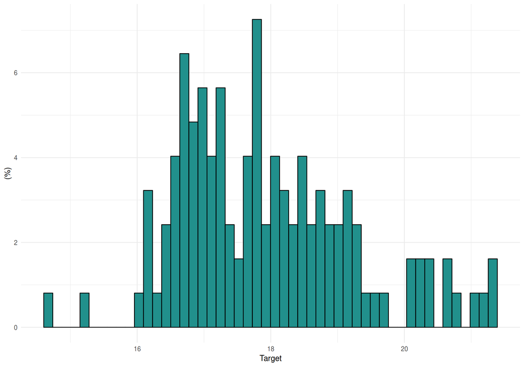

```r
train %>%
    select(fullVisitorId,transactionRevenue) %>%
    na.omit() %>%
    group_by(fullVisitorId) %>%
    summarise(logRevenue = log(sum(as.numeric(transactionRevenue)))) %>%
    ggplot(aes(x = logRevenue)) +
    geom_histogram(aes(y = 100*..count../sum(..count..)), colour = "black", fill = viridis(3)[[2]], bins = 50) +
    theme_minimal() +
    xlab("Target") +
    ylab("(%)")
```

It looks quite beatiful, but please note that we are - quite fairly - assuming that the missing values in the `transactionRevenue` column are simply an absence of transactions. Which is $0$ revenue.

```r
train[, transactionRevenue := ifelse(is.na(transactionRevenue), 0, transactionRevenue)]
```

> The Pareto principle - also known as the 80/20 rule - states that, for many events, roughly 80% of the effects come from 20% of the causes. And it is a consequent axiom of business management that *80% of sales come from 20% of clients*.

Reality is, most people we have recorded in the dataset don’t end up buying things in the store.

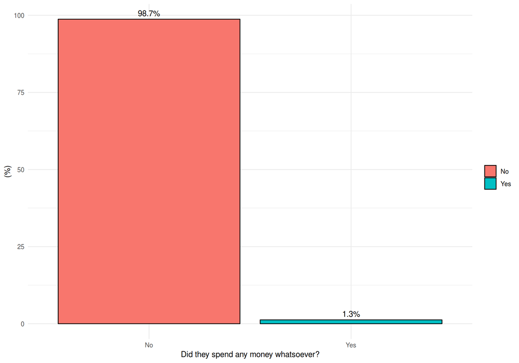

```r
train %>%
    select(fullVisitorId,transactionRevenue) %>%
    group_by(fullVisitorId) %>%
    summarise(logRevenue = (sum(as.numeric(transactionRevenue)))) %>%
    mutate(logRevenue = ifelse(logRevenue == 0, "No", "Yes")) %>%
    ggplot(aes(x = logRevenue,
                         fill = logRevenue)) +
    geom_bar(aes(y = 100*..count../sum(..count..)),
                     colour = "black"
                     ) +
    geom_text(aes(label = scales::percent(..count../sum(..count..)),
                                y= 100*..count../sum(..count..) ),
                        stat= "count",
                        vjust = -.5) +
    theme_minimal() +
    xlab("Did they spend any money whatsoever?") +
    ylab("(%)") +
    labs(fill = "")
```

What these numbers are suggesting is that, before even considering predicting *how much* money a customer is going to spend, we should begin by thinking *whether* a customer is going to spend *any money* whatsoever.

This detail is crucial because it forces us to not start by constructing a *regression model*, but a *classification* one.

## Time Dependence of the Target variable

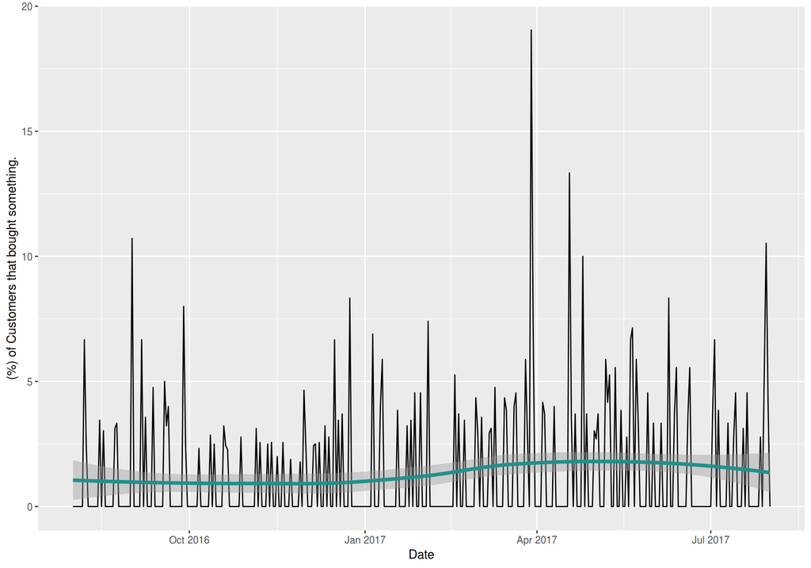

```r
train %>%
    group_by(fullVisitorId, date) %>%
    summarise(did_she_spend = sum(ifelse(transactionRevenue == 0, 0, 1))) %>%
    group_by(date) %>%
    summarise(payer_perc = 100*sum(did_she_spend)/n()) %>%
    ggplot(aes(x = ymd(date), y = payer_perc)) +
    geom_line(colour = "black", size = 0.5) +
    geom_smooth(method = "loess",
                            formula = y ~ x,
                            level = 0.9,
                            colour = viridis(3)[[2]],
                            size = 1.5) +
    ylab("(%) of Customers that bought something.") +
    xlab("Date")
```

What I really find interesting are the periodicity of some of the bounces. If you take a closer look at the plot, you can see that it has periodic spikes. I’d say that those spikes have to do with the day of the week.

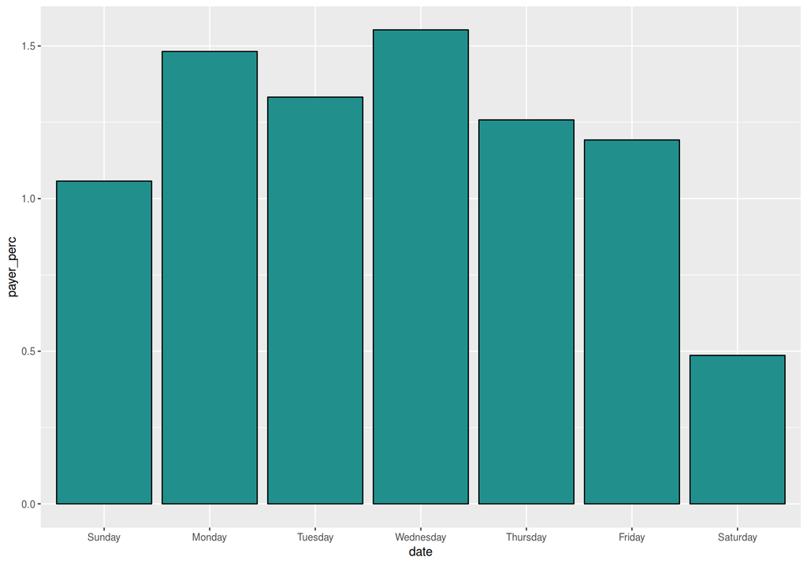

```r
train %>%
    mutate(date = date %>% ymd()) %>%
    group_by(fullVisitorId, date) %>%
    summarise(did_she_spend = sum(ifelse(transactionRevenue == 0, 0, 1))) %>%
    mutate(date = date %>% wday(label = TRUE, abbr = FALSE)) %>%
    group_by(date) %>%
    summarise(payer_perc = 100*sum(did_she_spend)/n()) %>%
    ggplot(aes(x = date,
                         y = payer_perc)) +
    geom_col(colour = "black",
                     fill = viridis(3)[[2]])
```

As I suspected, something happens during the weekends. My shot is that more “casual” people enter wandering at the store, just for browsing out of curiosity without any intention of buying anything in the first place. Yes, some people might end up buying something, but I expected that even though the gross number of customers increase on weekends, the percentage of them that buy something would drecrease.

This can be used as a feature. Since we should expect that a weekend customer is less likely to buy anything.

```r
train_class <- train %>%
    mutate(date = ymd(date)) %>%
    group_by(fullVisitorId, date) %>%
    mutate(target_class = sum(ifelse(transactionRevenue == 0, 0, 1))) %>%
    mutate(weekend = ifelse((date %>% wday(label = TRUE, abbr = FALSE)) %in% c("Saturday", "Sunday"),1,0)) %>%
    data.table()
```

# Classification Model

```r
fn <- funs(mean,
                     # sd,
                     # min,
                     # max,
                     # sum,
                     # n_distinct,
                     # kurtosis,
                     # skewness,
                     .args = list(na.rm = TRUE))
```

```r
train_class <- train %>%
    mutate(date = ymd(date)) %>%
    group_by(fullVisitorId, date) %>%
    mutate(target_class = sum(ifelse(transactionRevenue == 0, 0, 1))) %>%
    mutate(target_class = ifelse(target_class > 1, 1, target_class)) %>%
    as_tibble()

test_class <- test %>%
    mutate(date = ymd(date)) %>%
    group_by(fullVisitorId, date) %>%
    as_tibble()
```

By now, we should have noticed a big problem that we are facing here. Note that we have far more instances for `target_class == 0` than for `target_class == 1`. This is what we call *unbalanced data*. This is a problem, because any model that we might build will tend to label every output as `0`, in order to increase their accuracy. And that is going to get the model more accuracte, indeed; but is not going to be useful for us.

Imagine that you are building an AI model in order to spot and diagnose illnesses in people. An extremely accurate model would be one that *always* diagnoses no illness; a model that just claims that every person is healthy. That would be extremely accurate, wouldn’t it? After all, most people are healthy the vast majority of the time. Dspite being accurate, such a model turns out to be utterly useless, because is not telling you anything useful.

Anagolously, our model will tend to spot every possible customer as `non-payer`. Making the model accurate, but pointless.

There are a myriad of techniques in order to avoid it. For simplicity’s sake, we are going to use *oversampling*. This is a kind of [bootstrapping](https://en.wikipedia.org/wiki/Bootstrapping) technique, because we simply duplicate some of our instances, in order to balance the data a little bit.

```r
n_pos <- sum(train_class$target_class==1)
n_tot <- nrow(train_class)
train_positive <- train_class %>%
    filter(target_class == 1) %>%
    sample_n(size = floor((n_tot - n_pos)/(n_pos)), replace = TRUE)

train_class <- rbind(train_positive, train_class) %>% as_tibble()
```

## EDA

Note that these EDA is going to be made after resampling the data. That could seem utterly biased, and it is. The point is that, as long as we are aware of that, we’ll be ok. The purpose of this EDA is not simply to explore the data as it is, but to extract relevant features. Resampling the data lets us put the features in perspective. As we will see followingly, features evenly distributed (50-50) amongs those who paid something and those who didn’t, is telling us basically nothing that could help us predict the target.

### Weekends

The first variable that I’d like to explore is that one already spotted in the time dependence study of our data. A variable that tells us whether the customer came to the store during a weekend.

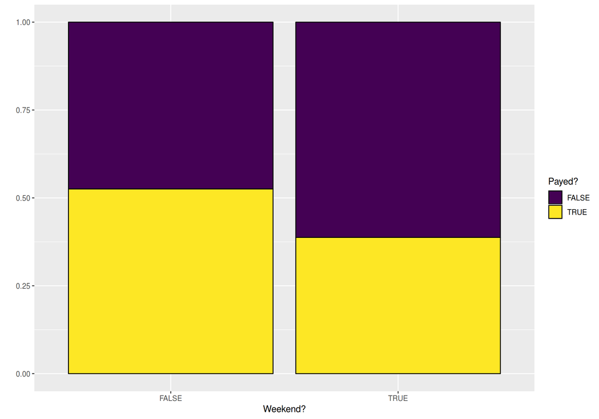

```r
train_class %>%
            mutate(weekend = ifelse((date %>% wday(label = TRUE, abbr = FALSE)) %in% c("Saturday", "Sunday"),TRUE,FALSE)) %>%
    ggplot(aes(x = as.factor(weekend), fill = target_class == 1)) +
    geom_bar(position = "fill", colour = "black") +
    scale_fill_viridis(discrete = TRUE, name = "Payed?") +
    xlab("Weekend?") +
    # scale_x_discrete(limits = c("FALSE", "TRUE")) +
    ylab("")
```

We can see that our common sense was somehow right, and the proportion of people that *didn’t* spend any money increases during the weekends.

### channelGrouping

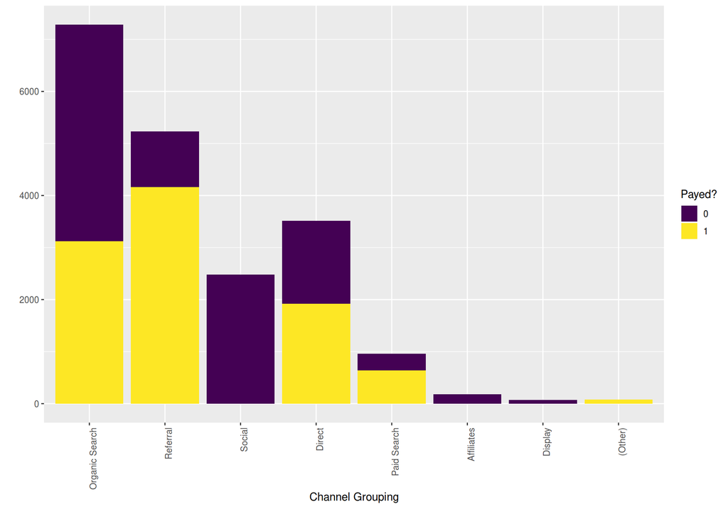

```r
train_class %>%
    group_by(channelGrouping, target_class) %>%
    summarise(value = n()) %>%
    ggplot(aes(y = value, x = reorder(channelGrouping, -value))) +
    geom_col(aes(fill = as.factor(target_class))) +
    theme(axis.text.x = element_text(angle = 90, hjust = 1)) +
    scale_fill_viridis(name = "Payed?", discrete = TRUE) +
    xlab("Channel Grouping") +
    ylab("")
```

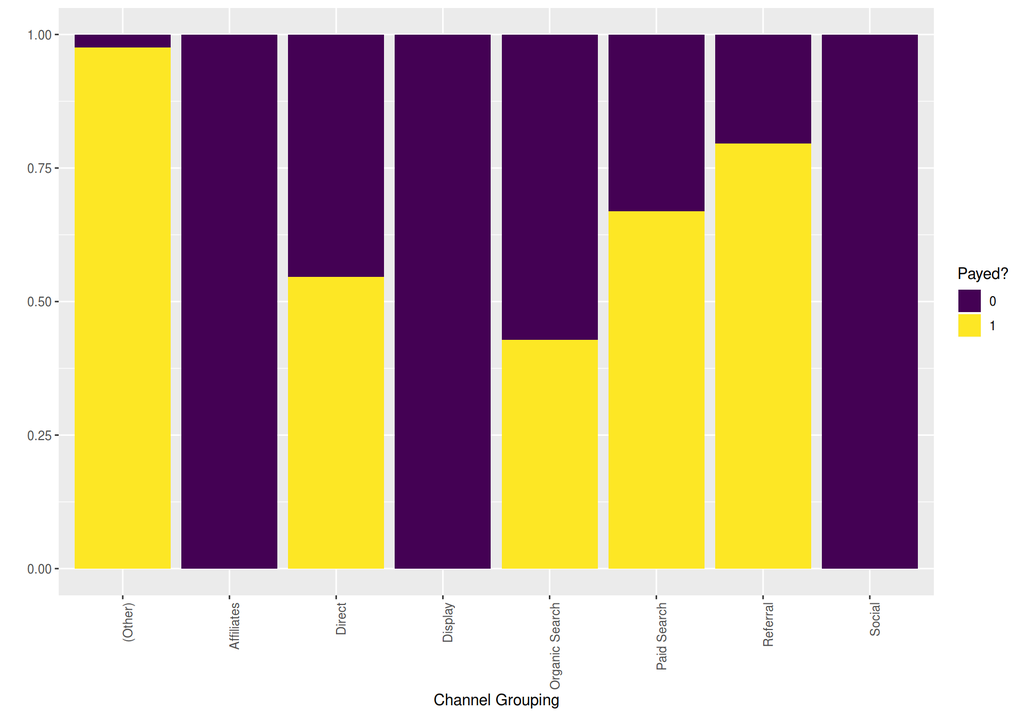

```r
train_class %>%
    ggplot(aes(x = channelGrouping, fill = as.factor(target_class))) +
    geom_bar(position = "fill") +
    theme(axis.text.x = element_text(angle = 90, hjust = 1)) +
    scale_fill_viridis(name = "Payed?", discrete = TRUE) +
    xlab("Channel Grouping") +
    ylab("")
```

The results are quite informative, don’t you think? It seems clear that people comming from `Referral` have a greater tendency to end up paying something than the average guy. We could say exactly the opposite for `Social`, since their results are plainly aweful.

The rest are confusing or non-informative. Either by a lack of data or because the distribution is evenly splitted.

### Browser

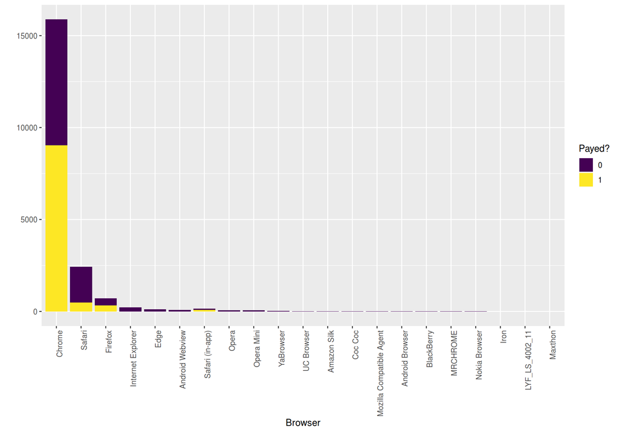

```r
train_class %>%
    group_by(browser, target_class) %>%
    summarise(value = n()) %>%
    ggplot(aes(y = value, x = reorder(browser, -value))) +
    geom_col(aes(fill = as.factor(target_class))) +
    theme(axis.text.x = element_text(angle = 90, hjust = 1)) +
    scale_fill_viridis(name = "Payed?", discrete = TRUE) +
    xlab("Browser") +
    ylab("")
```

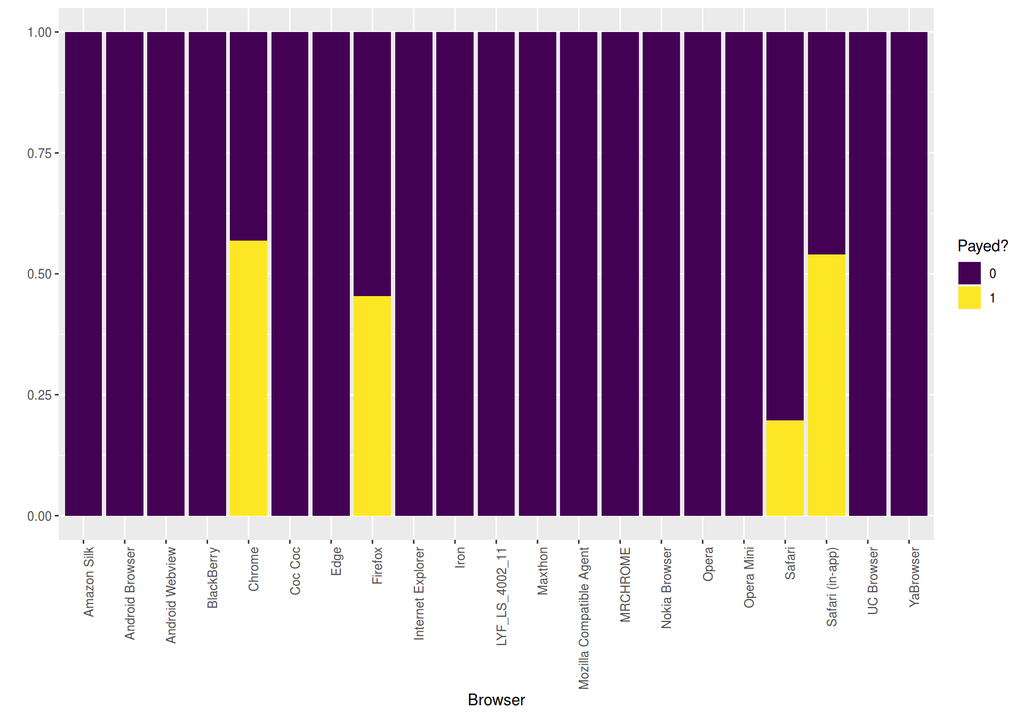

```r
train_class %>%
    ggplot(aes(x = browser, fill = as.factor(target_class))) +
    geom_bar(position = "fill") +
    theme(axis.text.x = element_text(angle = 90, hjust = 1)) +
    scale_fill_viridis(name = "Payed?", discrete = TRUE) +
    xlab("Browser") +
    ylab("")
```

If I have to be honest, I’d rather drop this feature. Almost everyone is using `Chrome`, which is splitted in the middle and tells us nothing. And the rest are so rare that any meaningful difference could be labeled as an outlier.

If we want to get a bit creative, we could think os simplifying this feature. We could say that from all these browsers we can distinguish `Chrome`, `No-Chrome-but-still-mainstream` and the rest. Let’s plot that and see if we can spot something useful.

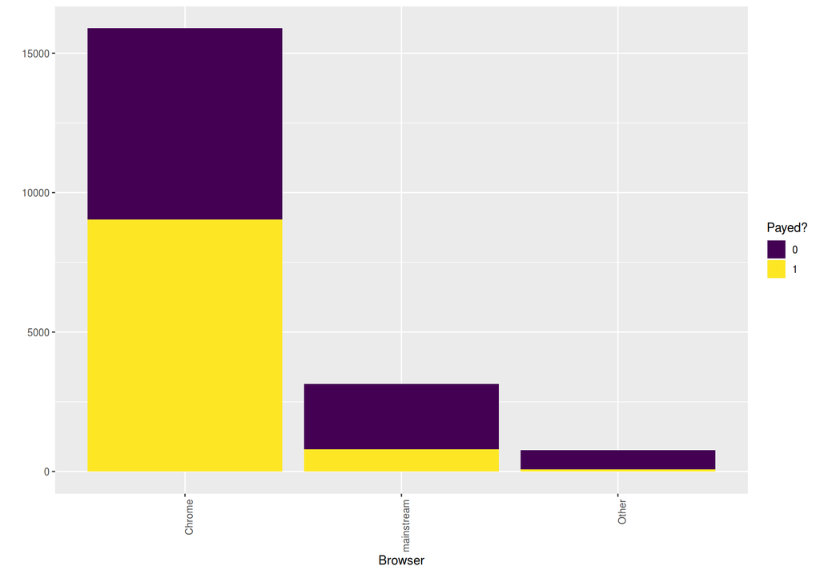

```r
train_class %>%
    mutate(browser = ifelse(browser %in% c("Safari", "Firefox"), "mainstream", ifelse(browser == "Chrome", 'Chrome', "Other"))) %>%
    group_by(browser, target_class) %>%
    summarise(value = n()) %>%
    ggplot(aes(y = value, x = reorder(browser, -value))) +
    geom_col(aes(fill = as.factor(target_class))) +
    theme(axis.text.x = element_text(angle = 90, hjust = 1)) +
    scale_fill_viridis(name = "Payed?", discrete = TRUE) +
    xlab("Browser") +
    ylab("")
```

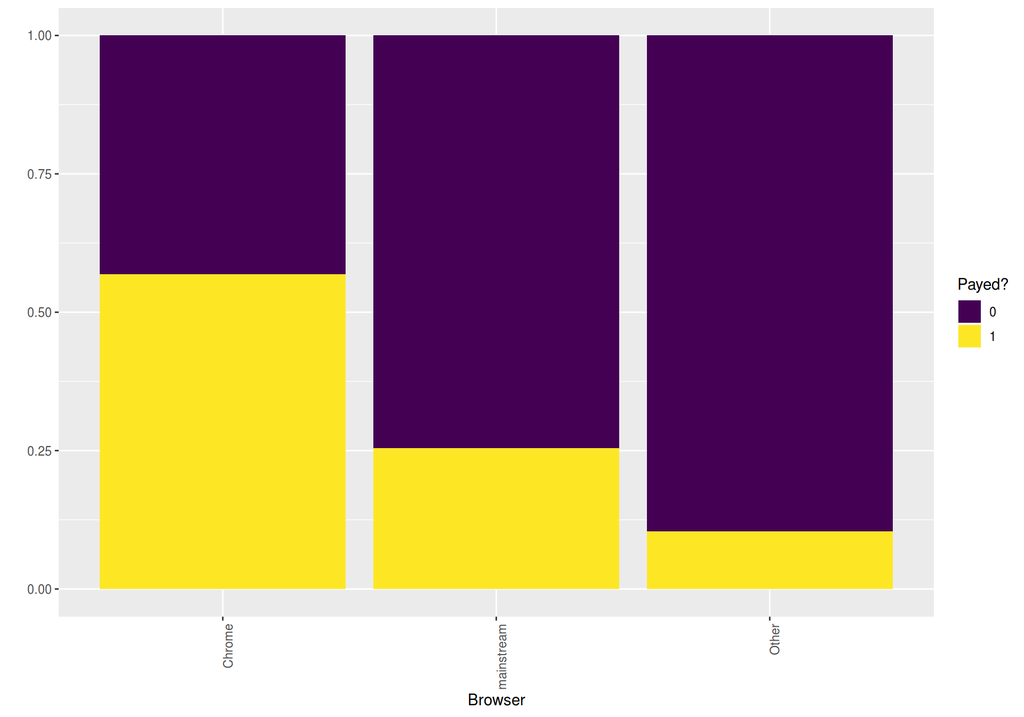

```r
train_class %>%
    mutate(browser = ifelse(browser %in% c("Safari", "Firefox"), "mainstream", ifelse(browser == "Chrome", 'Chrome', "Other"))) %>%
    group_by(browser, target_class) %>%
    ggplot(aes(x = browser, fill = as.factor(target_class))) +
    geom_bar(position = "fill") +
    theme(axis.text.x = element_text(angle = 90, hjust = 1)) +
    scale_fill_viridis(name = "Payed?", discrete = TRUE) +
    xlab("Browser") +
    ylab("")
```

We should remember that *Chrome* is - hands down - the most used browser both in pc and smartphones. And that after all, we are talking about a Merchandising Google Store. Chances are, that if our customer is not using *Chrome*, she might be not a big fan of Google.

At this point I would just build a feature of type boolean that tracks whether the customer is using `Chrome` or not. And leave it there.

### Source/Medium variable

#### Medium

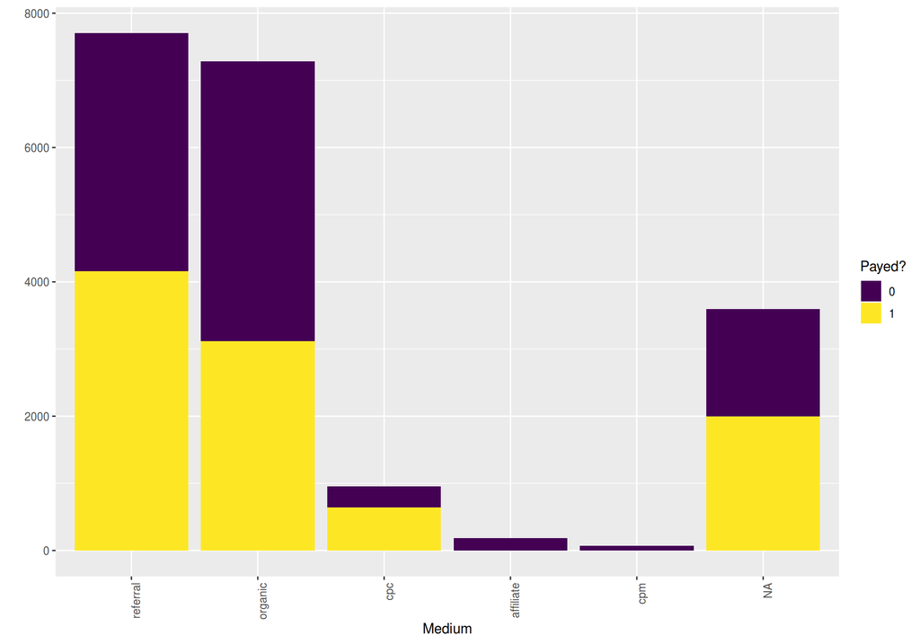

```r
train_class %>%
    group_by(medium, target_class) %>%
    summarise(value = n()) %>%
    ggplot(aes(y = value, x = reorder(medium, -value))) +
    geom_col(aes(fill = as.factor(target_class))) +
    theme(axis.text.x = element_text(angle = 90, hjust = 1)) +
    scale_fill_viridis(name = "Payed?", discrete = TRUE) +
    xlab("Medium") +
    ylab("")
```

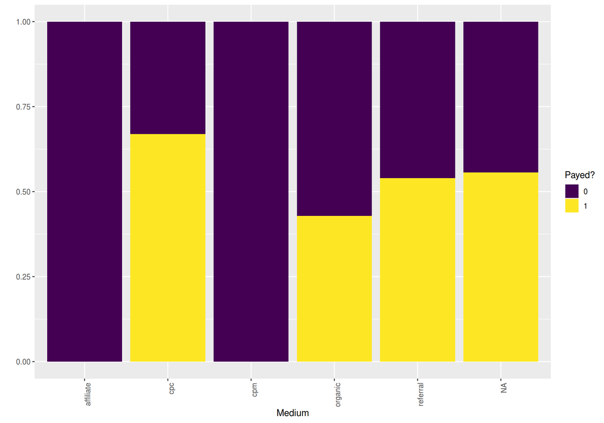

```r
train_class %>%
    ggplot(aes(x = medium, fill = as.factor(target_class))) +
    geom_bar(position = "fill") +
    theme(axis.text.x = element_text(angle = 90, hjust = 1)) +
    scale_fill_viridis(name = "Payed?", discrete = TRUE) +
    xlab("Medium") +
    ylab("")
```

#### Source

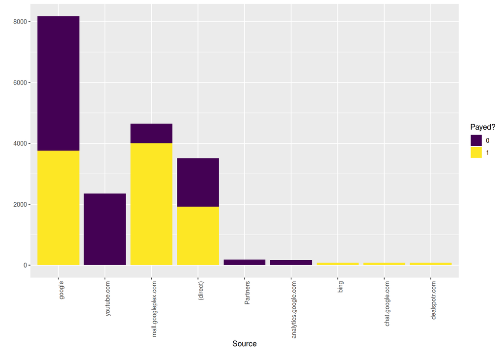

```r
train_class %>%
    group_by(source, target_class) %>%
    summarise(value = n()) %>%
    ungroup() %>%
    top_n(10, value) %>%
    ggplot(aes(y = value, x = reorder(source, -value))) +
    geom_col(aes(fill = as.factor(target_class))) +
    theme(axis.text.x = element_text(angle = 90, hjust = 1)) +
    scale_fill_viridis(name = "Payed?", discrete = TRUE) +
    xlab("Source") +
    ylab("")
```

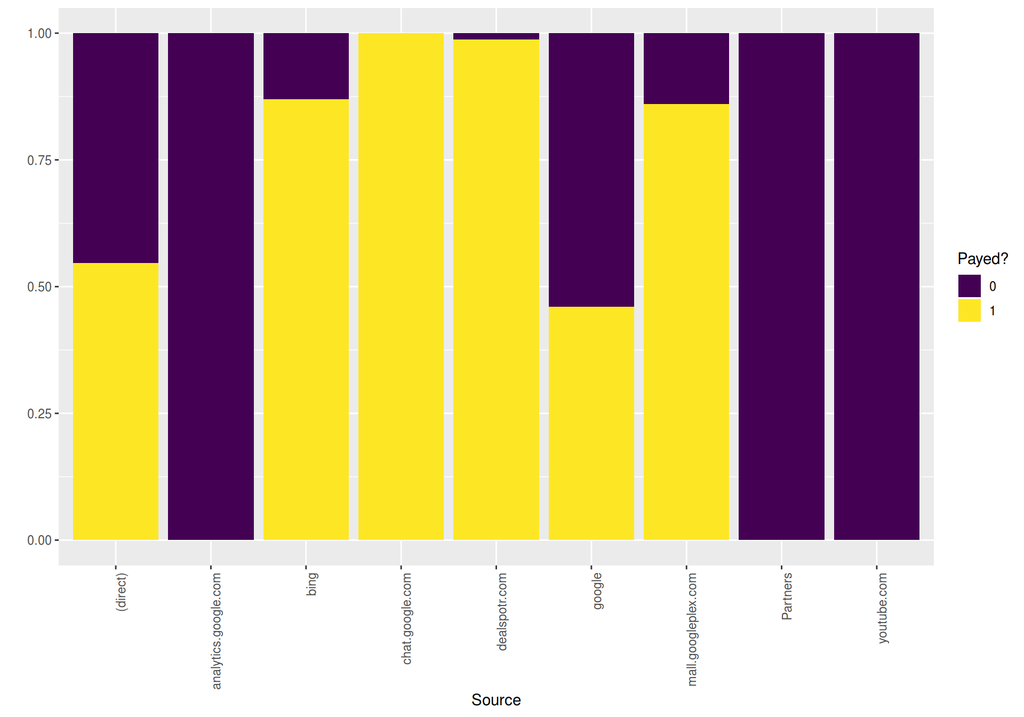

```r
top_sources <- train_class %>%
    group_by(source, target_class) %>%
    summarise(value = n()) %>%
    ungroup() %>%
    top_n(10, value) %>%
    .$source

train_class %>%
    filter(source %in% top_sources) %>%
    ggplot(aes(x = source, fill = as.factor(target_class))) +
    geom_bar(position = "fill") +
    theme(axis.text.x = element_text(angle = 90, hjust = 1)) +
    scale_fill_viridis(name = "Payed?", discrete = TRUE) +
    xlab("Source") +
    ylab("")
```

On the other hand, we have the *Source*. Which tells from which place the traffic came from. Note that I limited the plot to the top 10 with more customers, because the list of sources is humongous; and most of them have so small numbers that we couldn’t say anything useful from it.

See that the source `mail.googleplex.com` is incredibly efficient. It streams a lot of traffic and almost everyone is paying something. Even though we have the data rebalanced, that is impressive. On the contrary, `youtubecom` seems like a poor source to drag customers from.

#### Source/Medium Variable

In [this](https://www.kaggle.com/erikbruin/google-analytics-eda-lightgbm-screenshots) fantastic Kernel, I saw that the author created a new variable combining both the `Source` and the `Medium`, which could be a significant feature for a model.

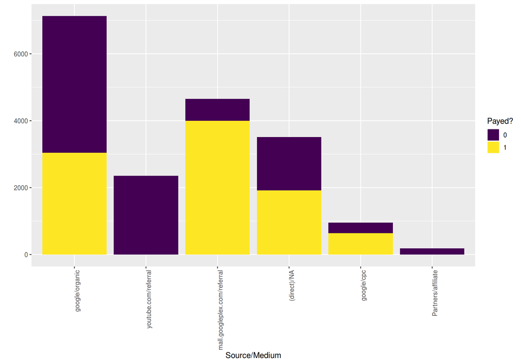

```r
train_class %>%
    mutate(source_medium = paste(source, medium, sep="/")) %>%
    group_by(source_medium, target_class) %>%
    summarise(value = n()) %>%
    ungroup() %>%
    top_n(10, value) %>%
    ggplot(aes(y = value, x = reorder(source_medium, -value))) +
    geom_col(aes(fill = as.factor(target_class))) +
    theme(axis.text.x = element_text(angle = 90, hjust = 1)) +
    scale_fill_viridis(name = "Payed?", discrete = TRUE) +
    xlab("Source/Medium") +
    ylab("")
```

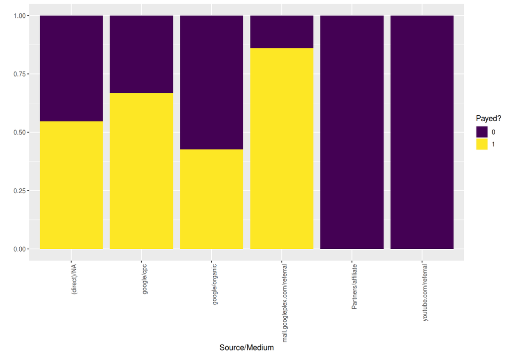

```r
top_sourcemediums <- train_class %>%
    mutate(source_medium = paste(source, medium, sep="/")) %>%
    group_by(source_medium, target_class) %>%
    summarise(value = n()) %>%
    ungroup() %>%
    top_n(10, value) %>%
    .$source_medium

train_class %>%
    mutate(source_medium = paste(source, medium, sep="/")) %>%
    filter(source_medium %in% top_sourcemediums) %>%
    ggplot(aes(x = source_medium, fill = as.factor(target_class))) +
    geom_bar(position = "fill") +
    theme(axis.text.x = element_text(angle = 90, hjust = 1)) +
    scale_fill_viridis(name = "Payed?", discrete = TRUE) +
    xlab("Source/Medium") +
    ylab("")
```

However, the results are not much different that those that could be extracted from just the `Source`. Actually, the main important factors that I see here are whether the customer has come from the googleplex mail service, or whether the customer has come from youtube. One is positive and the other is negative, and that is all - the rest might be just for overfitting.

So I would rather not adding this new feature yet.

### Device

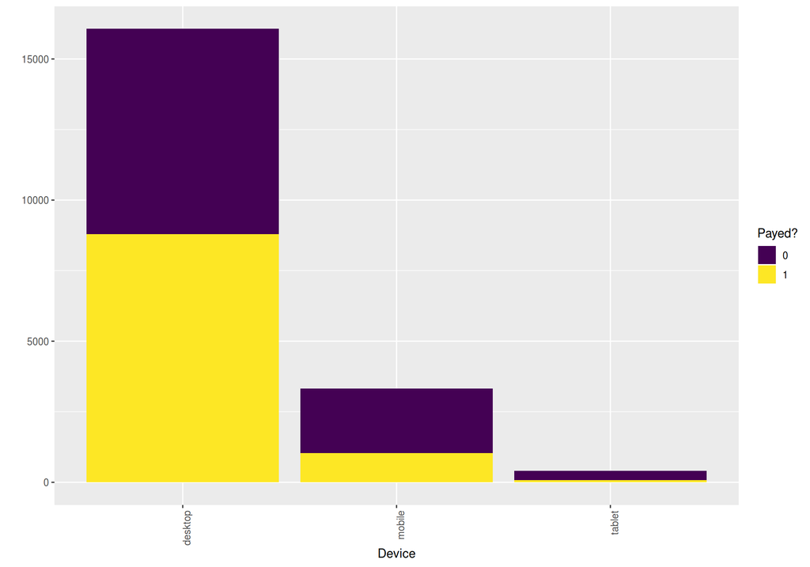

```r
train_class %>%
    group_by(deviceCategory, target_class) %>%
    summarise(value = n()) %>%
    ggplot(aes(y = value, x = reorder(deviceCategory, -value))) +
    geom_col(aes(fill = as.factor(target_class))) +
    theme(axis.text.x = element_text(angle = 90, hjust = 1)) +
    scale_fill_viridis(name = "Payed?", discrete = TRUE) +
    xlab("Device") +
    ylab("")
```

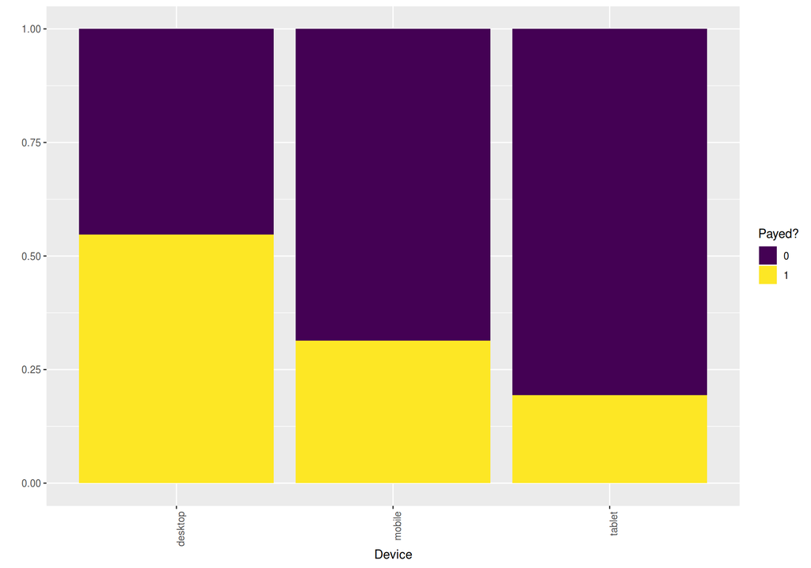

```r
train_class %>%
    ggplot(aes(x = deviceCategory, fill = as.factor(target_class))) +
    geom_bar(position = "fill") +
    theme(axis.text.x = element_text(angle = 90, hjust = 1)) +
    scale_fill_viridis(name = "Payed?", discrete = TRUE) +
    xlab("Device") +
    ylab("")
```

As you might have noted by now, I like to simplify. In this feature I see a main driver: Whether a user is using the desktop or not. Mobile and Tablt interactions seem a bit more casual, less oriented to end up buying something. So I would suggest to build another boolean feature that jusks asks whether a user is in their desktop or not.

### Operating System

As it has happened before, we have too many options, and most of them have simply not enough instances. So we are going to filter the top most important ones.

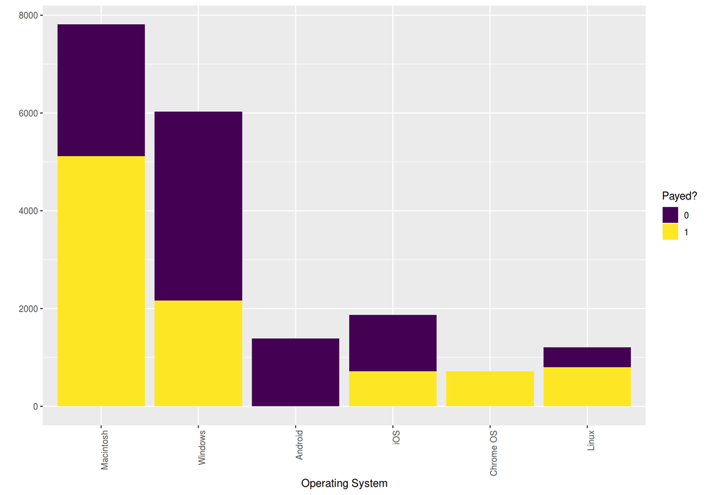

```r
train_class %>%
    group_by(operatingSystem, target_class) %>%
    summarise(value = n()) %>%
    ungroup() %>%
    top_n(10, value) %>%
    ggplot(aes(y = value, x = reorder(operatingSystem, -value))) +
    geom_col(aes(fill = as.factor(target_class))) +
    theme(axis.text.x = element_text(angle = 90, hjust = 1)) +
    scale_fill_viridis(name = "Payed?", discrete = TRUE) +
    xlab("Operating System") +
    ylab("")
```

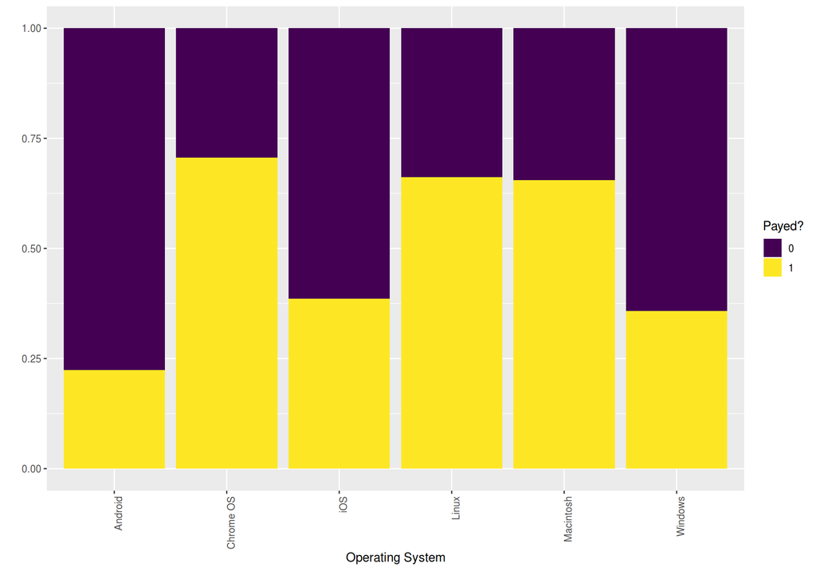

```r
top_os <- train_class %>%
    group_by(operatingSystem, target_class) %>%
    summarise(value = n()) %>%
    ungroup() %>%
    top_n(10, value) %>%
    .$operatingSystem

train_class %>%
    filter(operatingSystem %in% top_os) %>%
    ggplot(aes(x = operatingSystem, fill = as.factor(target_class))) +
    geom_bar(position = "fill") +
    theme(axis.text.x = element_text(angle = 90, hjust = 1)) +
    scale_fill_viridis(name = "Payed?", discrete = TRUE) +
    xlab("Operating System") +
    ylab("")
```

Now be careful because it seems easier than it is. Note that before this, we have stated that desktop users have more odds to end up buying something. And now we can see that users from `Chrome OS`, `Linux` and `Macintosh` also have higher chances. See the pattern? We are just seeing the same as before. If we decided to say that this is another useful variable, we would be fooling ourselves. This is just redundant information.

But we can do a bit of magic, and filter in/out the desktop users and see how this changes.

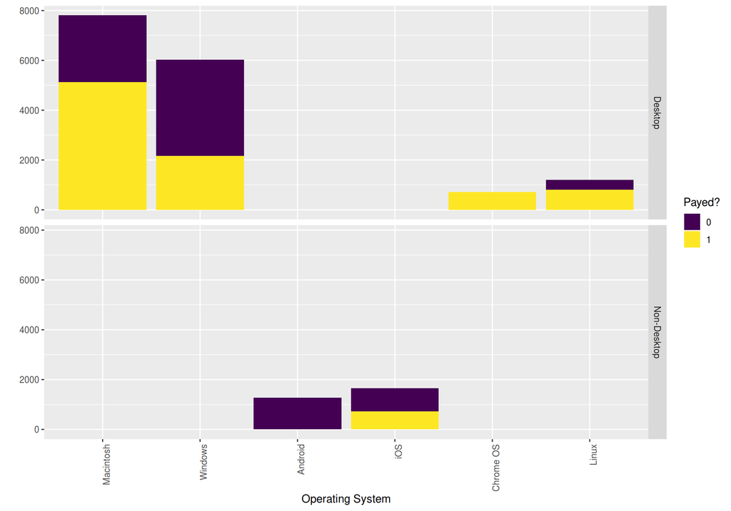

```r
train_class %>%
    group_by(operatingSystem, target_class, deviceCategory) %>%
    summarise(value = n()) %>%
    ungroup() %>%
    top_n(10, value) %>%
    ggplot(aes(y = value, x = reorder(operatingSystem, -value))) +
    geom_col(aes(fill = as.factor(target_class))) +
    theme(axis.text.x = element_text(angle = 90, hjust = 1)) +
    scale_fill_viridis(name = "Payed?", discrete = TRUE) +
    xlab("Operating System") +
    ylab("") +
    facet_grid(ifelse(deviceCategory == 'desktop', "Desktop", "Non-Desktop") ~.)
```

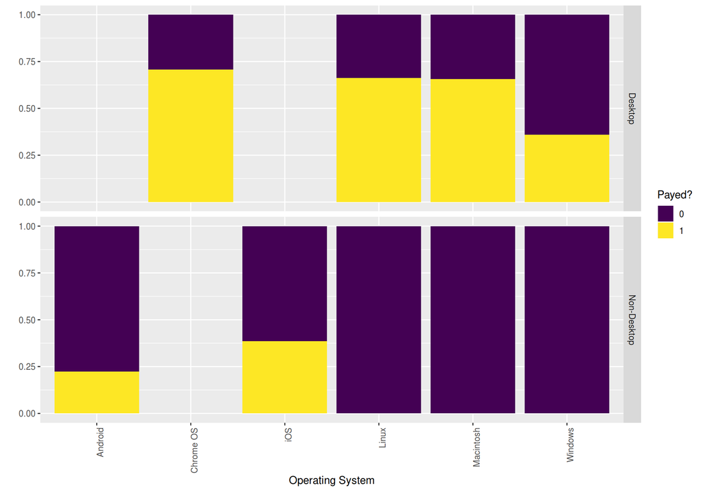

```r
top_os <- train_class %>%
    # filter(deviceCategory == "desktop") %>%
    group_by(operatingSystem, target_class) %>%
    summarise(value = n()) %>%
    ungroup() %>%
    top_n(10, value) %>%
    .$operatingSystem

train_class %>%
    filter(operatingSystem %in% top_os) %>%
    ggplot(aes(x = operatingSystem, fill = as.factor(target_class))) +
    geom_bar(position = "fill") +
    theme(axis.text.x = element_text(angle = 90, hjust = 1)) +
    scale_fill_viridis(name = "Payed?", discrete = TRUE) +
    xlab("Operating System") +
    ylab("") +
    facet_grid(ifelse(deviceCategory == 'desktop', "Desktop", "Non-Desktop") ~.)
```

People that is interested in actually buying goodies in the GStore aren’t casual users, are mostly geeks. We can see that in the astonishing proportion appearing in `Chrome OS` and `Linux`, and quite impressive numbers in the `Macintosh`. The more *casual* the operating system is - and less developer preferred -, the less proportion of customers end up spending money.

The interactions between `Operating System` and whether the device is a `Dekstop` are interesting and informative, we should use them.

### Visit Number

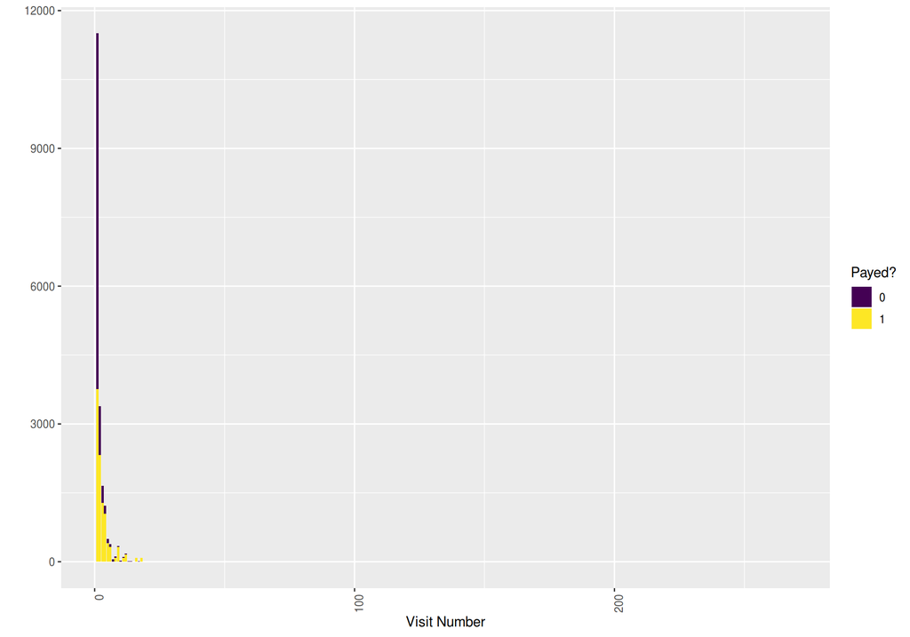

```r
train_class %>%
    group_by(visitNumber, target_class) %>%
    summarise(value = n()) %>%
    ggplot(aes(y = value, x = visitNumber)) +
    geom_col(aes(fill = as.factor(target_class))) +
    theme(axis.text.x = element_text(angle = 90, hjust = 1)) +
    scale_fill_viridis(name = "Payed?", discrete = TRUE) +
    xlab("Visit Number") +
    ylab("")
```

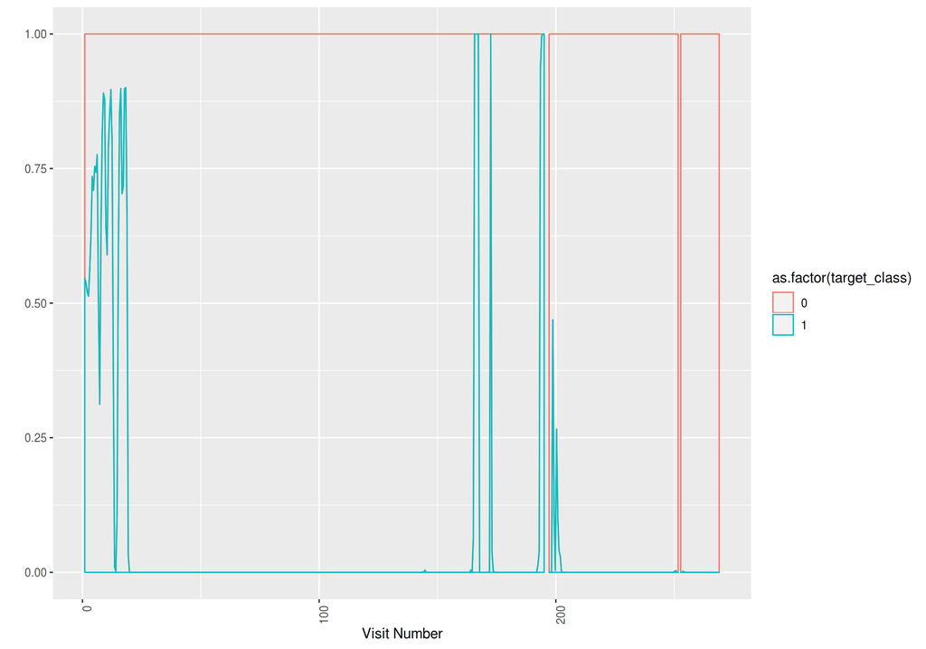

```r
train_class %>%
    ggplot(aes(x = visitNumber, colour = as.factor(target_class))) +
    geom_density(position = "fill") +
    theme(axis.text.x = element_text(angle = 90, hjust = 1)) +
    scale_fill_viridis(name = "Payed?", discrete = TRUE) +
    xlab("Visit Number") +
    ylab("")
```

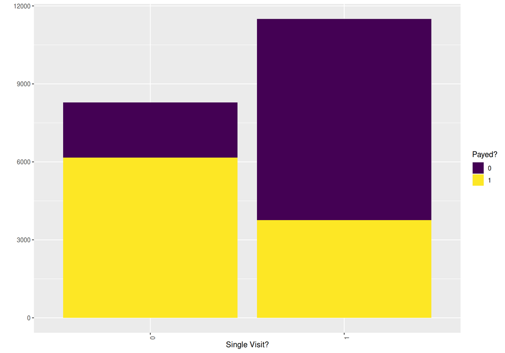

```r
train_class %>%
    mutate(single_visit = ifelse(visitNumber == 1,1,0)) %>%
    group_by(single_visit, target_class) %>%
    summarise(value = n()) %>%
    ggplot(aes(y = value, x = as.factor(single_visit))) +
    geom_col(aes(fill = as.factor(target_class))) +
    theme(axis.text.x = element_text(angle = 90, hjust = 1)) +
    scale_fill_viridis(name = "Payed?", discrete = TRUE) +
    xlab("Single Visit?") +
    ylab("")
```

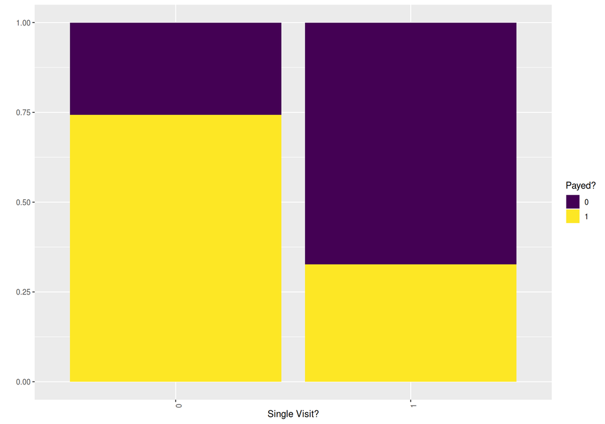

```r
train_class %>%
    mutate(single_visit = ifelse(visitNumber == 1,1,0)) %>%
    ggplot(aes(x = as.factor(single_visit), fill = as.factor(target_class))) +
    geom_bar(position = "fill") +
    theme(axis.text.x = element_text(angle = 90, hjust = 1)) +
    scale_fill_viridis(name = "Payed?", discrete = TRUE) +
    xlab("Single Visit?") +
    ylab("")
```

## Feature Engineering

Based on our EDA, we can fairly construct these features

```r
tri <- 1:nrow(train_class)
y <- train_class$target_class %>% as.numeric()

outersect <- function(x, y) {
  sort(c(setdiff(x, y),
         setdiff(y, x)))
}

tmp <- outersect(colnames(train_class),colnames(test_class))


tr_te <- train_class[ , -which(names(train_class) %in% tmp)] %>%
    rbind(test_class) %>%
    data.table()

# rm(train_class, test_class, tmp)
gc()
```

```
##            used  (Mb) gc trigger  (Mb) max used  (Mb)
## Ncells  2862568 152.9    7557738 403.7  7557738 403.7
## Vcells 10176038  77.7   34806672 265.6 43504433 332.0
```

```r
tr_te[, weekend := ifelse((date %>% wday(label = TRUE, abbr = FALSE)) %in% c("Saturday", "Sunday"),1,0)]
tr_te[, browser := ifelse(browser %in% c("Safari", "Firefox"), "mainstream", ifelse(browser == "Chrome", 'Chrome', "Other"))]
tr_te[, is_chrome_the_browser := ifelse(browser == "Chrome", 1, 0) %>% as.numeric()]
tr_te[, browser := NULL]
tr_te[, source_from_googleplex := ifelse(source == 'mail.googleplex.com', 1, 0) %>% as.numeric()]
tr_te[, source_from_youtube := ifelse(source == 'youtube.com', 1, 0) %>% as.numeric()]
tr_te[, source := NULL]
tr_te[, is_medium_referral := ifelse(medium == 'referral', 1, 0) %>% as.numeric()]
tr_te[, medium := NULL]
tr_te[, is_device_desktop := ifelse(deviceCategory == 'desktop', 1, 0) %>% as.numeric()]
tr_te[, is_device_macbook := is_device_desktop*ifelse(operatingSystem == "Macintosh", 1, 0)]
tr_te[, windows_desktop := is_device_desktop*ifelse(operatingSystem == 'Windows', 1, 0)]
tr_te[, is_device_chromebook := ifelse(operatingSystem == "Chrome OS", 1, 0)]
tr_te[, is_device_linux := ifelse(operatingSystem == "Linux", 1, 0)]
tr_te[, is_phone_ios := ifelse(operatingSystem == "iOS", 1, 0)]
tr_te[, is_phone_android := ifelse(operatingSystem == "Android", 1, 0)]
tr_te[, operatingSystem := NULL]
tr_te[, deviceCategory := NULL]
tr_te[, single_visit := ifelse(visitNumber == 1,1,0) ]

tr_te[,which(unlist(lapply(tr_te, function(x)!all(is.na(x))))),with=F]
```

[output not shown]

[output cut: 141 more lines]

```r
tr_te <- tr_te %>%
    group_by(fullVisitorId, date) %>%
    mutate_if(is.character, funs(factor(.) %>% as.integer)) %>%
    summarise_all(fn) %>%
    as_tibble()
```

## XG Boost

```r
tri_val <- caret::createDataPartition(y, p = 0.9, list = F) %>% c()
```

Preparing Data

```r
trte_xgb <- tr_te %>%
    ungroup() %>%
    dplyr::select(-fullVisitorId,-date,-visitId,-visitStartTime, -sessionId) %>%
    data.matrix()

#XGB Matrices
dtest_xgb <- xgb.DMatrix(data = trte_xgb[-tri, ])
trte_xgb_xgb <- trte_xgb[tri, ]
dtrain_xgb <- xgb.DMatrix(data = trte_xgb[tri, ], label = y[tri])
dval_xgb <- xgb.DMatrix(data = trte_xgb_xgb[-tri_val, ], label = y[-tri_val])
cols_xgb <- colnames(trte_xgb)

rm(trte_xgb, tri); gc()
```

```
##            used  (Mb) gc trigger  (Mb) max used  (Mb)
## Ncells  2864532 153.0    7557738 403.7  7557738 403.7
## Vcells 11294607  86.2   34806672 265.6 43504433 332.0
```

Training the actual model

```r
p <- list(objective = "binary:logistic",
                    booster = "gbtree",
                    eval_metric = "auc",
                    nthread = 4,
                    eta = 0.001,
                    max_depth = 6,
                    min_child_weight = 30,
                    gamma = 0,
                    subsample = 0.85,
                    colsample_bytree = 0.7,
                    colsample_bylevel = 0.632,
                    alpha = 0,
                    lambda = 0,
                    nrounds = 2000)

m_xgb <- xgb.train(p, dtrain_xgb, p$nrounds, list(val = dval_xgb), print_every_n = 50, early_stopping_rounds = 500)
```

```
## Will train until val_auc hasn't improved in 500 rounds.
##
```

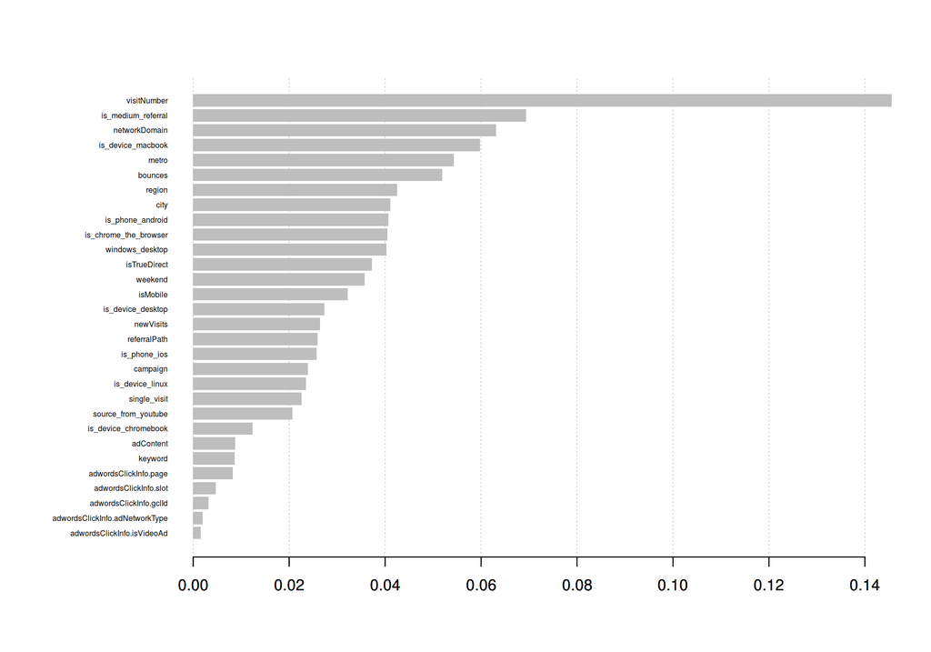

```r
xgb.importance(cols_xgb, model=m_xgb) %>%
    xgb.plot.importance(top_n = 50)
```

```r
# Hyperparameter Tuning XGB---------------------------------------------------
#---------------------------


parameterList <- expand.grid(subsample = seq(from = 0.5, to = 1, by = 0.25),
                                                         colsample_bytree = seq(from = 0.4, to = 1, by = 0.2),
                                                         lr = seq(from = 2, to = 10, by = 1),
                                                         mtd = seq(from = 4, to = 10, by = 2))
ntrees <- 100

scores <- c()

rmseErrorsHyperparameters <- for(i in 1:nrow(parameterList)){

    #Extract Parameters to test
    currentSubsampleRate <- parameterList[["subsample"]][[i]]
    currentColsampleRate <- parameterList[["colsample_bytree"]][[i]]
    lr <- parameterList[["lr"]][[i]]
    mtd <- parameterList[["mtd"]][[i]]

    p <- list(objective = "binary:logistic",
                        booster = "gbtree",
                        eval_metric = "auc",
                        nthread = 4,
                        eta = lr/ntrees,
                        max_depth = mtd,
                        min_child_weight = 30,
                        gamma = 0,
                        subsample = currentSubsampleRate,
                        colsample_bytree = currentColsampleRate,
                        colsample_bylevel = 0.632,
                        alpha = 0,
                        lambda = 0,
                        nrounds = ntrees)
    tic()
    xgb_cv <- xgb.cv(p, dtrain_xgb, p$nrounds, print_every_n = 5, early_stopping_rounds = 25, nfold = 5)
    toc()
    cat(paste0("... ", i/nrow(parameterList)*100, " (%)  ... \n"))
    scores[i] <- xgb_cv$evaluation_log$test_auc_mean %>% max()
}
```

[output not shown]

[output cut: 2949 more lines]

```
## ... 99.537037037037 (%)  ...
## Multiple eval metrics are present. Will use test_auc for early stopping.
## Will train until test_auc hasn't improved in 25 rounds.
##
## Stopping. Best iteration:
##
## 3.14 sec elapsed
## ... 99.7685185185185 (%)  ...
## Multiple eval metrics are present. Will use test_auc for early stopping.
## Will train until test_auc hasn't improved in 25 rounds.
##
## Stopping. Best iteration:
##
## 2.082 sec elapsed
## ... 100 (%)  ...
```

```r
m <- which.max(scores)
currentSubsampleRate <- parameterList[["subsample"]][[m]]
currentColsampleRate <- parameterList[["colsample_bytree"]][[m]]
lr <- parameterList[["lr"]][[m]]
mtd <- parameterList[["mtd"]][[m]]

ntrees <- 2000
p <- list(objective = "binary:logistic",
                    booster = "gbtree",
                    eval_metric = "auc",
                    nthread = 4,
                    eta = lr/ntrees,
                    max_depth = mtd,
                    min_child_weight = 30,
                    gamma = 0,
                    subsample = currentSubsampleRate,
                    colsample_bytree = currentColsampleRate,
                    colsample_bylevel = 0.632,
                    alpha = 0,
                    lambda = 0,
                    nrounds = ntrees)

m_xgb <- xgb.train(p, dtrain_xgb, p$nrounds, list(val = dval_xgb), print_every_n = 50, early_stopping_rounds = 500)
```

```
## Will train until val_auc hasn't improved in 500 rounds.
##
```

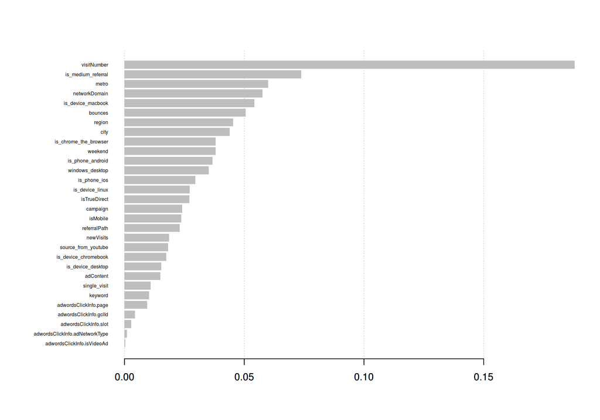

```r
xgb.importance(cols_xgb, model=m_xgb) %>%
    xgb.plot.importance(top_n = 50)
```

```r
# probs <- predict(m_xgb, dtest_xgb)
# predictions <- (probs > 0.5) %>% as.numeric()
#
# predictions <- predictions %>%
#   as_tibble() %>%
#   rename_(predict_label = names(.)[1]) %>%
#   tibble::rownames_to_column()
#
# correct_pred <- train_class %>%
#   tibble::rownames_to_column() %>%
#   left_join(predictions) %>%
#   filter(predict_label == target_class)
#
# explainer <- lime(correct_pred, model = m_xgb,
#                   preprocess = as.numeric)
```